# MINT Microbial Case Study

This case study will focus on applying the P-integrative framework (MINT) to a set of microbial data, derived from two different studies. The ultimate goal is to generate a sPLS-DA model which can determine what inhibiting agent a given microbiome inhabitant has been affected by based on signals present in OTU (**O**perational **T**axonomic **U**nit) readings.

# Rscript

The R script used for all the analysis in this case study is available [here](http://mixomics.org/wp-content/uploads/2022/02/MINT-Microbial-Case-Study.zip).

# To begin

Load the latest version of `mixOmics`.

```r
library(mixOmics) # import the mixOmics library
```

## The data

The data being used in the case study derives from anaerobic respiration inhibition research. There are a total of four studies included in this data [Poirier S. et al., 2018(a), Poirier S. et al., 2018(b)], measured across the same set of OTUs. They were compiled and analysed in conjunction [Poirier S. et al., 2020]. Certain microbiome inhabitants can have their anaerobic respiration inhibited by the presence of certain substrates. These studies focused on the impact of ammonia (NH4) on this process.

Download the data [here](http://mixomics.org/wp-content/uploads/2022/02/MINT-Microbial-Data.zip). The `data_prediction_data.RData` file contains the following dataframes:

- `metadata_studies_1_2` (continuous and categotical matrix): 55 rows and 40 columns. Contains much of the metadata for each of the samples *for studies 1 and 2*. For this case study, only variables used from this dataframe is the `experiment` feature (denotes which study each sample is drawn from) and `inhib_inoc` feature (denotes the type of inhibition for that sample).
- `metadata_studies_3_4` (continuous and categotical matrix): 46 rows and 40 columns. Contains much of the metadata for each of the samples *for studies 3 and 4*. For this case study, only variables used from this dataframe is the `experiment` feature (denotes which study each sample is drawn from) and `inhib_inoc` feature (denotes the type of inhibition for that sample).
- `abundance_studies_1_2` (continuous matrix): 51 rows and 55 columns. Contains the raw OTU (rows) values for each of the samples (columns) *for studies 1 and 2*.
- `abundance_studies_3_4` (continuous matrix): 51 rows and 46 columns. Contains the raw OTU (rows) values for each of the samples (columns) *for studies 3 and 4*.

```r
load("Microbial Data/data_prediction_data.RData") # load the data

# extract the Y vectors
treatment.1.2 <- metadata_studies_1_2$inhib_inoc
treatment.3.4 <- metadata_studies_3_4$inhib_inoc
treatment <- c(treatment.1.2, treatment.3.4)

# extract the study each sample is from
study.1.2 <- metadata_studies_1_2$experiment
study.3.4 <- metadata_studies_3_4$experiment
study <- c(study.1.2,study.3.4)

# combine abundance datasets into a single dataframe
abundance <- cbind(abundance_studies_1_2, abundance_studies_3_4)
```

## Pre-processing the data

While this case study is not using the mixMC framework, the concepts from [MixMC Pre-processing](http://mixomics.org/mixmc-methodology/mixmc-preprocessing/) are still valid as the data is microbial in nature. Hence, the same steps outlined in that page will be followed here.

First an offset was applied to prevent the presence of any zeroes. Then, features with significantly low counts were to be removed to avoid any spurious conclusions - however none fell below the threshold and therefore none were removed. Finally, a CLR (centered log ratio) transformation was applied.

## Data exploration

### PCA

Looking at the projection of the samples in the PC space (Figure 1), the samples from different study are more or less separated. This is a clear example of a batch effect - a bias in the data where the distribution differences across studies outweighs the distribution differences between classes. This is exactly what needs to be controlled by the MINT methodology. Figure 1 suggests the classes can be separated, but the significant overlap of the confidence ellipses indicates that a much better model can be developed.

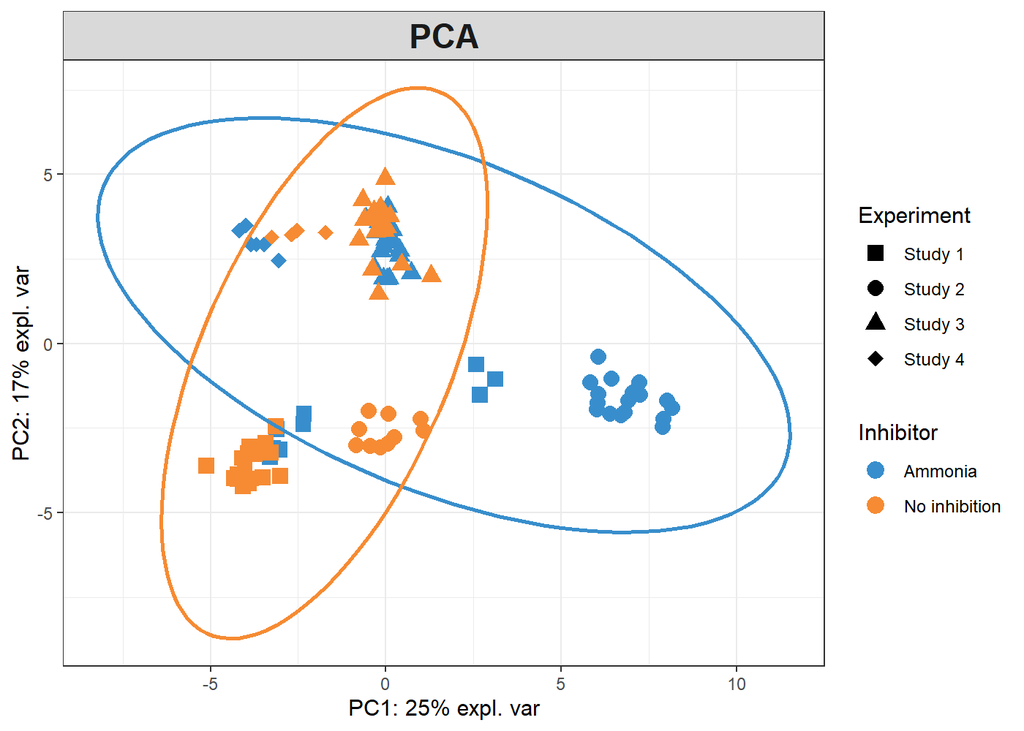

```r
# undergo PCA
ab.pca <- pca(abundance.processed, scale = TRUE, center = TRUE, ncomp = 5)

# plot projection of samples in PC space
plotIndiv(ab.pca, group=treatment,
          ind.names = F,legend=T,
          pch = as.numeric(factor(study))+14,
          pch.levels=(study), ellipse = TRUE,
          title="PCA",legend.title = "Inhibitor",
          legend.title.pch = "Experiment", size.legend = rel(2.4),
          size.legend.title = rel(2.5))
```

## MINT sPLS-DA Model

Now that the data have been explored, and the experimental effect identified, the next step involves the use of the MINT framework. Prior to this however, the data shall be once again split. The first two studies will be used as training data while the third and fourth studies are to be used as a validation set.

```r
# determine indices of training and testing sets
train.idx <- which(study %in% c("Study 1", "Study 2"))
test.idx <- which(study %in% c("Study 3", "Study 4"))

# separate the predictors
X.train <- abundance.processed[train.idx, ]
X.test <- abundance.processed[test.idx, ]

# separate the class labels
Y.train <- treatment[train.idx]
Y.test <- treatment[test.idx]

# separate the study associations
study.train <- as.factor(as.character(study[train.idx]))
study.test <- as.factor(as.character(study[test.idx]))
```

### Tuning the model

Using just the training data, the model is first tuned. Observing the error rates for each `keepX` on each component, the minimum is achieved by `keepX = 17` on the first component. Addition of the second to fifth components actually make no improvements over a model with one component. However, as visualisation is desired, a minimum component count of 2 will be used. Note that the lines depicting components 3 and 4 are not visible as they are the exact same as the fifth component (which is rendered on top of these two).

```r
# tune the ncomp and keepX parameters for the MINT sPLS-DA model
ab.mint.splsda.tuning <- tune(method = "mint.splsda",
                              X = X.train,
                              Y = Y.train,
                              study = study.train,
                              ncomp = 5,
                              test.keepX = seq(5,50, 3),
                              measure = 'BER', # balanced error rate
                              dist = "centroids.dist")
```

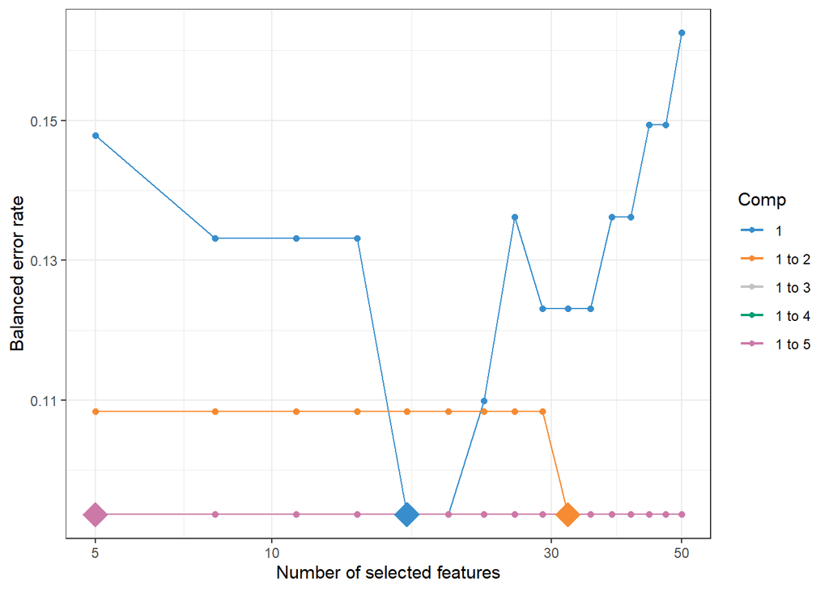

```r
plot(ab.mint.splsda.tuning, sd = FALSE) # sd = F due to LOO CV
```

FIGURE 2: Tuning plot of the MINT sPLS-DA models with up to 5 components. Diamonds represent the optimal number of features on a given component. Balanced error rate found on the vertical axis and is the metric to be minimised.

```r
optimal.ncomp <- 2

# extract the optimal keepX parameter
optimal.keepX <- ab.mint.splsda.tuning$choice.keepX[1:optimal.ncomp]

optimal.keepX
```

```
## comp1 comp2
##    17    32
```

### Training the model on studies 1 and 2

Using the tuned parameter values, a model is generated and trained on the first two studies.

```r
# form tuned, trained MINT sPLS-DA model
ab.mint.splsda <- mint.splsda(X = X.train, Y = Y.train,
                              ncomp = optimal.ncomp, keepX = optimal.keepX,
                              study = study.train)
```

### Visualising the model

#### Sample Plots

As always, the plot to start with is the sample projection plot. Figure 3 depicts the projection of the samples onto the ‘global’ variates, that which represent all studies. The placebo group has the studies separated along the first component while the studies are separated along the second component for the ammonia samples. Hence, the batch effect is still slightly present, but its impacts within each class have been severely reduced. The class distinction is significantly better than that of Figure 1 as they are linearly separable with the confidence ellipses sharing no overlap.

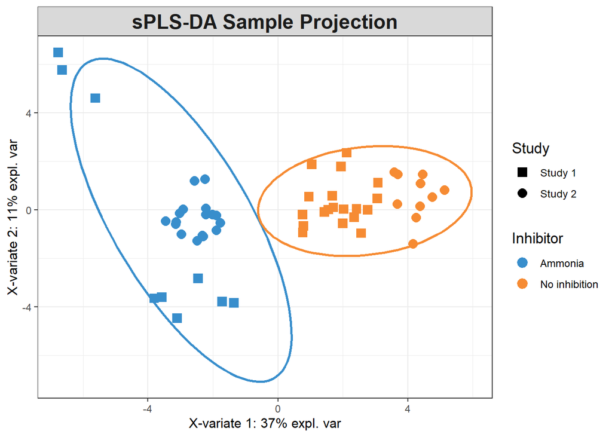

```r
plotIndiv(ab.mint.splsda, ind.names = F,legend=T,
          pch = as.numeric(factor(study.train))+14,
          pch.levels=study.train,
          ellipse = T,
          subtitle="sPLS-DA Sample Projection",legend.title = "Inhibitor",
          legend.title.pch = "Experiment",
          size.legend = rel(0.8))
```

FIGURE 3: Projection of the samples from both studies onto the global variates yielded by MINT sPLS-DA.

#### Variable Plots

Understanding how the model has constructed the variates is an important step in learning how these classes are distinct. When considering global component 1 (Figure 4(a)), the association of each variable with a specific class is clear. Positively contributing features are exclusively associated with the `no inhibition` class while all negatively contributing features defined the `ammonia` group. This suggests that the first component (in the global space) is key in discriminating between these two classes. The functionality of the second component is not as clear, but Figure 4(b) does show the features which are the most important to this component.

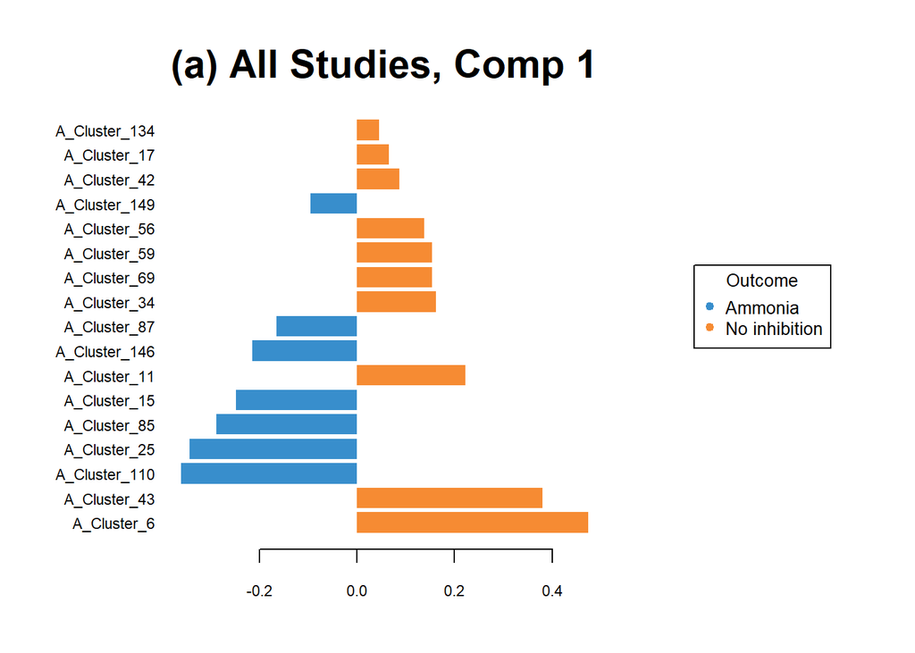

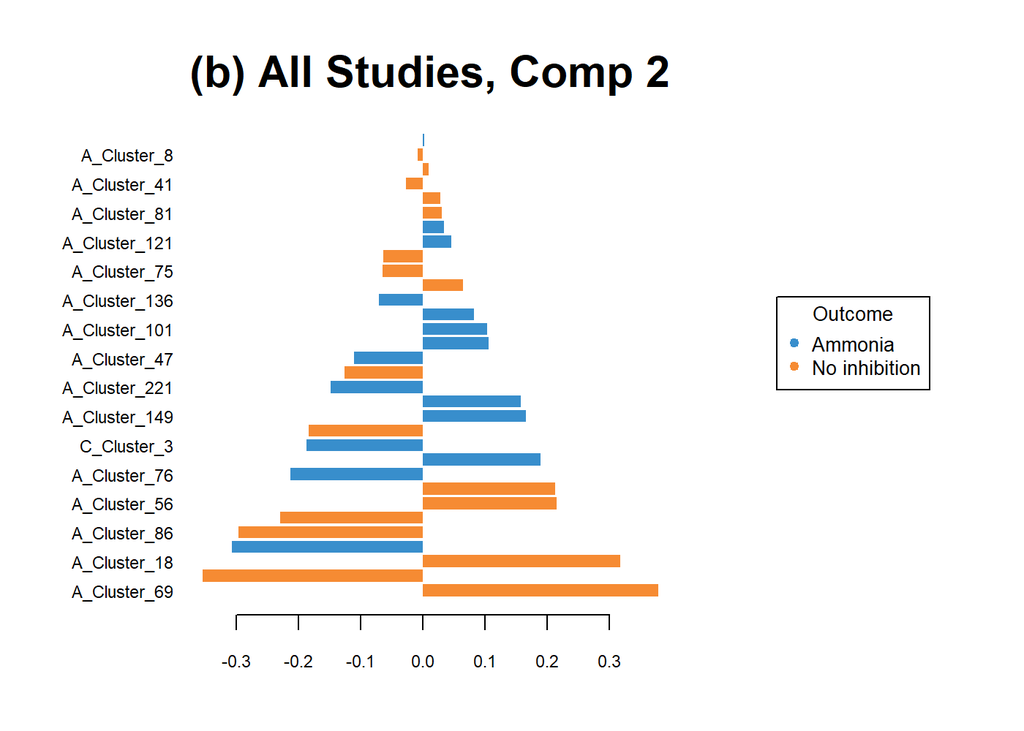

```r
plotLoadings(ab.mint.splsda, method = "median", comp = 1,
             legend = T, study = "global", contrib = "max",
             title = "(a) All Studies, Comp 1")

plotLoadings(ab.mint.splsda, method = "median", comp = 2,
             legend = T, study = "global", contrib = "max",
             title = "(b) All Studies, Comp 2")
```

FIGURE 4: Feature loading values on the global, first (a) and second (b) component. Bars coloured based on the treatment class with the highest median on that variable.

The correlation circle plot (Figure 5) shows that a majority of the selected features have strong associations (both positive and negative) with the first component. There is a smaller set of those which define the second component. Those on the negative side of the first component are more tightly clustered, suggesting features that define the ammonia class are more homogeneous and the placebo group has signals that are more disparate.

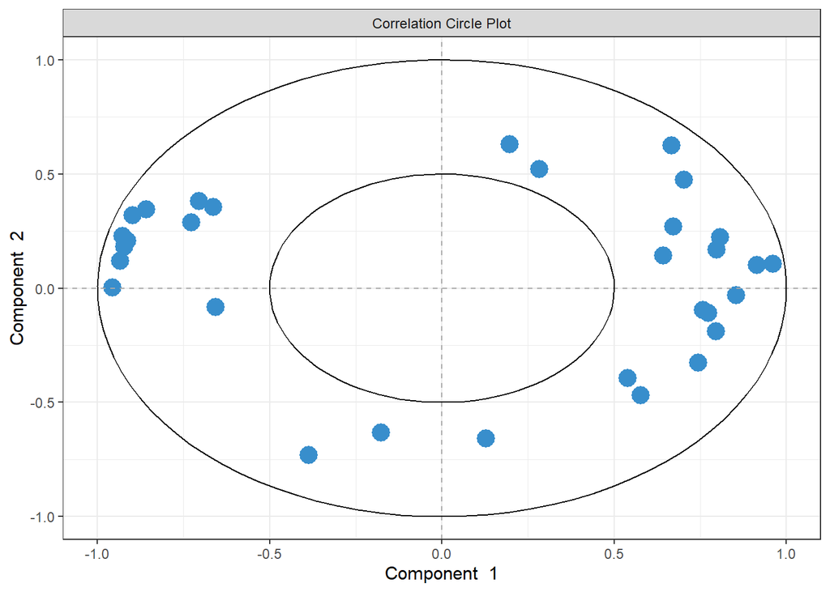

```r
plotVar(ab.mint.splsda, var.names = FALSE,
        pch = 16, cutoff = 0.5)
```

FIGURE 5: Correlation circle plot representing the OTUs selected by MINT sPLS-DA performed on the microbial data to examine the association of the selected OTUs on the first two components. A minimum correlation value of 0.5 is required to be depicted on these axes.

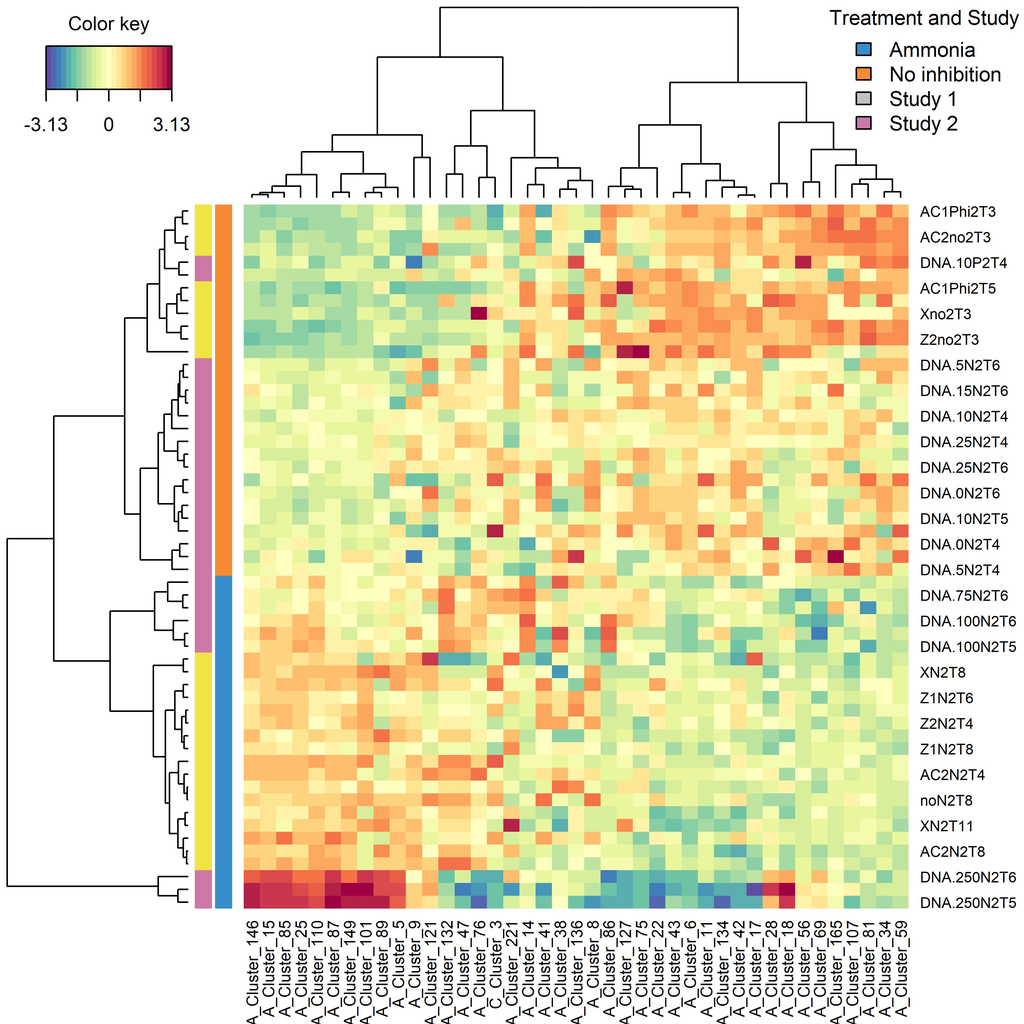

```r
cim(ab.mint.splsda,
    row.sideColors = cbind(color.mixo(as.numeric(Y.train)),
                           color.mixo(as.numeric(study.train)+4)),

    legend = list(legend = cbind(c(levels(Y.train)), c(levels(study.train))),
                col = cbind(c(color.mixo(1:2)), c(color.mixo(5:6))),
                title = "Treatment and Study", cex = 0.8)
    )
```

Lastly, the relevance network plot can be used to further understand the relationship between variables and classes. Note that `cutoff = 0.7`, such that any correlations below this value are not displayed at all. Being unable to control the position of the nodes in this plot makes interpretation more difficult. However, a key takeaway from this network is that all features with strong correlations (ie. above 0.7) have a positive association with one of the two classes and a negative association with the other.

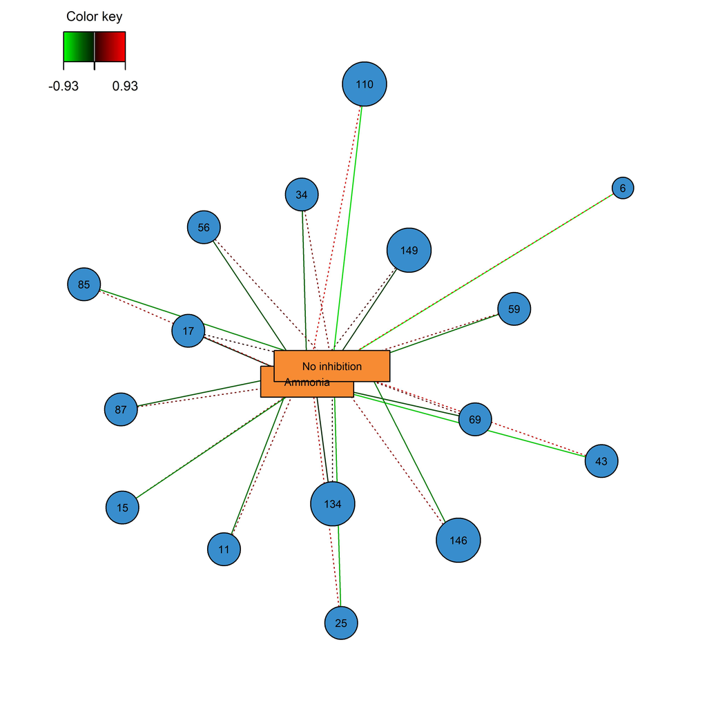

```r
network(ab.mint.splsda, cutoff = 0.7, comp = 1,
        color.node = c(color.mixo(1), color.mixo(2)),
        shape.node = c("circle", "rectangle"),
        lty.edge = c("dotted", "solid"),
        cex.node.name = 0.7,
        alpha.node = 0.5,
        row.names = names)
```

FIGURE 7: Relevance network of the selected features on the first component by MINT sPLS-DA performed on the microbial OTU data. Dotted, red lines are positive while solid, green lines are negative. Minimum correlation value of 0.7 required to be shown.

### Testing the model on studies 3 and 4

After the model has been explored, it’s performance as a classifier is to be assessed. Here, the `perf()` function is used to determine which distance metric will be most appropriate to use. Addition of the second component either has no impact on the model performance, or in the case of the mahalanobis distance, worsened performance. Based on Figure 8, classification error rate is minimised using `max.dist`.

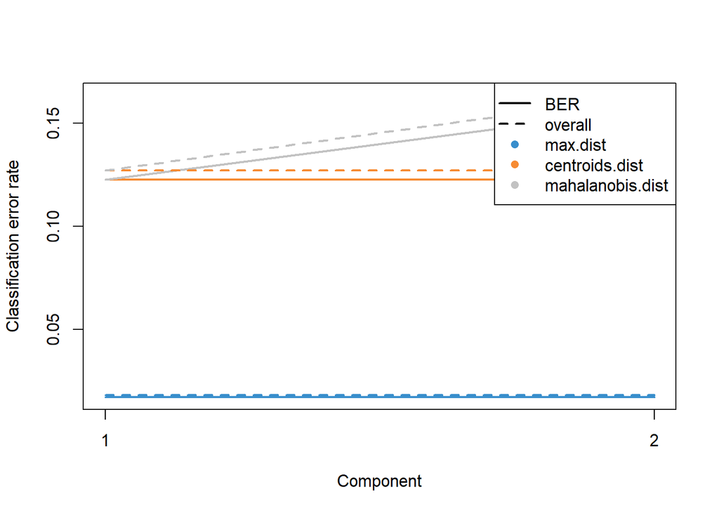

```r
ab.mint.splsda.perf <- perf(ab.mint.splsda, folds = 5, nrepeat = 10)
plot(ab.mint.splsda.perf)
```

FIGURE 8: Classification error rate of the MINT sPLS-DA models, using up to two components for all three distance metrics.

Using the model generated above and the `predict()` function, predictions of the class labels for all samples from studies 3 and 4 can be made.

```r
# make predictions of stem cell type of study 3 samples
predict.splsda <- predict(ab.mint.splsda, newdata = X.test,
                             dist = "max.dist",
                             study.test = study.test)
```

As can be seen below, the error rate and balanced error both decrease with the addition of the second component, though the model was already quite good at classifying these novel samples with just one component. This is unsurprising as looking at Figure 3, the first component separated the two classes entirely.

```r
YieldErrorRates(1)
```

```
## Metrics for model with 1 component(s):
## Error rate:  0.173913
## Balanced error rate:  0.1711538
```

```r
YieldErrorRates(2)
```

```
## Metrics for model with 2 component(s):
## Error rate:  0.08695652
## Balanced error rate:  0.09423077
```

Below, Figure 9 goes to show that sometimes the AUROC plot can show off some misleading results. For models using either one or both components the AUC is 1 despite the fact that the error rate wasn’t 0.

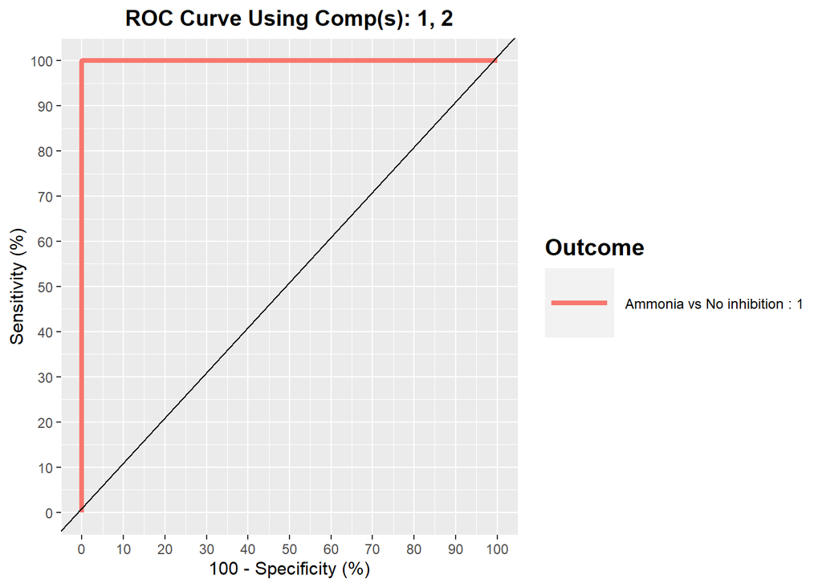

```r
auroc(ab.mint.splsda, roc.comp = 2, print = FALSE)
```

FIGURE 9 ROC curve and AUC from the MINT sPLS-DA performed on the microbial OTU data using both components. Numerical output on right is the AUC values for the model.

# More information on Plots

For a more in depth explanation of how to use and interpret the plots seen, refer to the following pages:

- [`plotIndiv()` - Sample Plot](http://mixomics.org/graphics/sample-plots/plotindiv/)
- [`plotLoadings()` - Loadings Plot](http://mixomics.org/graphics/plotloadings/)
- [`plotVar()` - Correlation Circle Plot](http://mixomics.org/graphics/variable-plots/plotvar/)
- [`cim()` - Cluster Image Maps](http://mixomics.org/graphics/variable-plots/cim/)
- [`network()` - Relevance Network Graph](http://mixomics.org/graphics/variable-plots/network/)

# References

- [Poirier S. and Chapleur O. Influence of support media supplementation to reduce the inhibition of anaerobic digestion by phenol and ammonia: Effect on degradation performances and microbial dynamics. Data in Brief. 2018; 19: 1733-1754.](https://www.ncbi.nlm.nih.gov/pmc/articles/PMC6141368/)
- [Poirier S. and Chapleur O. Inhibition of anaerobic digestion by phenol and ammonia: Effect on degradation performances and microbial dynamics. Data in Brief. 2018: 2235-2239.](https://www.researchgate.net/publication/326229855_Inhibition_of_anaerobic_digestion_by_phenol_and_ammonia_Effect_on_degradation_performances_and_microbial_dynamics)
- [Poirier S, Déjean, S, Midoux, C, Lê Cao K-A, Chapleur O (2020). Integrating independent microbial studies to build predictive models of anaerobic digestion inhibition by ammonia and phenol. Bioresource Technology 316:123952](https://www.researchgate.net/publication/343412985_Integrating_independent_microbial_studies_to_build_predictive_models_of_anaerobic_digestion_inhibition_by_ammonia_and_phenol)